# Lab 01

Jiapeng Guo

May 6, 2020

### Arithmetic

In the first code block, use R to perform the following arithmetic operations.

- $13+5$
- $\frac{7}{3}$
- $14^3$

```r
# Note that you can run an individual code chunk by clicking on the green arrow over here -->
# Instead of knitting the entire document, you can work on little bits of code first!

# Write your code below
#(a)
13 + 5
```

```
## [1] 18
```

```r
#(b)
7 / 3
```

```
## [1] 2.333333
```

```r
#(c)
14^3
```

```
## [1] 2744
```

### Variable Assignments

In the second code block, use R, to complete the following variable assignments.

```r
# Write your code below
# (a)
x = 6
y = 5
x + y
```

```
## [1] 11
```

```r
#(b)
x = y
x + y
```

```
## [1] 10
```

```r
#(c)
y = 8

# it does not affect the value of x
```

### Data Types

In the third code block, use R to explore different data types.

- Create three variables `myName`, `myPets`, and `myState`. Assign them your name, the number of pets your family has, and whether you are from Michigan (`TRUE` if you are from Michigan, `FALSE` otherwise). Note, you will need to wrap your name in double quotes.
- Check the type of each variable using the `class()` function

```r
# Write your code below
#(a)
myName = 'Jiapeng'
myPets = 0
myState = FALSE

#(b)
class(myName)
```

```
## [1] "character"
```

```r
class(myPets)
```

```
## [1] "numeric"
```

```r
class(myState)
```

```
## [1] "logical"
```

### Basic Data Exploration

In the fourth code block, use R to explore the built-in data set ‘mtcars’. This data contains aspects of automobile design and performance for a sample of cars from 1974.

- Using the `summary()` function, create numerical summaries for the entire data set.
- Use the `View()` function to look at the data. Calling `View()` should be done in the console below, not in the R Markdown file. No work is required for this task.
- Are more cars automatic (`am = 0`) or manual (`am = 1`)? Get the answer by using the `table()` function. Note: to reference a specific variable, use the format `data$variable`.
- What is the standard deviation of the variable fuel efficiency (`mpg`)? Use the function `sd()`.
- What is the highest horsepower to weight ratio (i.e. `hp:wt`)? Note: generate a new variable that represents this ratio, then use the `max()` function to find the maximum ratio.
- Use the `plot()` function to create a scatterplot of fuel efficiency (`mpg`) versus weight (`wt`). Use the inputs `xlab` and `ylab` to give the plot proper $x$ and $y$-labels.

```r
# The data set 'mtcars' has already been loaded into the workspace at the top of the file

# Write your code below
#(a)
summary(mtcars)
```

```
##       mpg             cyl             disp             hp
##  Min.   :10.40   Min.   :4.000   Min.   : 71.1   Min.   : 52.0
##  1st Qu.:15.43   1st Qu.:4.000   1st Qu.:120.8   1st Qu.: 96.5
##  Median :19.20   Median :6.000   Median :196.3   Median :123.0
##  Mean   :20.09   Mean   :6.188   Mean   :230.7   Mean   :146.7
##  3rd Qu.:22.80   3rd Qu.:8.000   3rd Qu.:326.0   3rd Qu.:180.0
##  Max.   :33.90   Max.   :8.000   Max.   :472.0   Max.   :335.0
##       drat             wt             qsec             vs
##  Min.   :2.760   Min.   :1.513   Min.   :14.50   Min.   :0.0000
##  1st Qu.:3.080   1st Qu.:2.581   1st Qu.:16.89   1st Qu.:0.0000
##  Median :3.695   Median :3.325   Median :17.71   Median :0.0000
##  Mean   :3.597   Mean   :3.217   Mean   :17.85   Mean   :0.4375
##  3rd Qu.:3.920   3rd Qu.:3.610   3rd Qu.:18.90   3rd Qu.:1.0000
##  Max.   :4.930   Max.   :5.424   Max.   :22.90   Max.   :1.0000
##        am              gear            carb
##  Min.   :0.0000   Min.   :3.000   Min.   :1.000
##  1st Qu.:0.0000   1st Qu.:3.000   1st Qu.:2.000
##  Median :0.0000   Median :4.000   Median :2.000
##  Mean   :0.4062   Mean   :3.688   Mean   :2.812
##  3rd Qu.:1.0000   3rd Qu.:4.000   3rd Qu.:4.000
##  Max.   :1.0000   Max.   :5.000   Max.   :8.000
```

```r
#(b)
table(mtcars$am)
```

```
##
##  0  1
## 19 13
```

```r
# There are more cars that are automatic than cars that are manual

#(c)
sd(mtcars$mpg)
```

```
## [1] 6.026948
```

```r
#(d)
mtcars$ratio = mtcars$hp / mtcars$wt
max(mtcars$ratio)
```

```
## [1] 93.83754
```

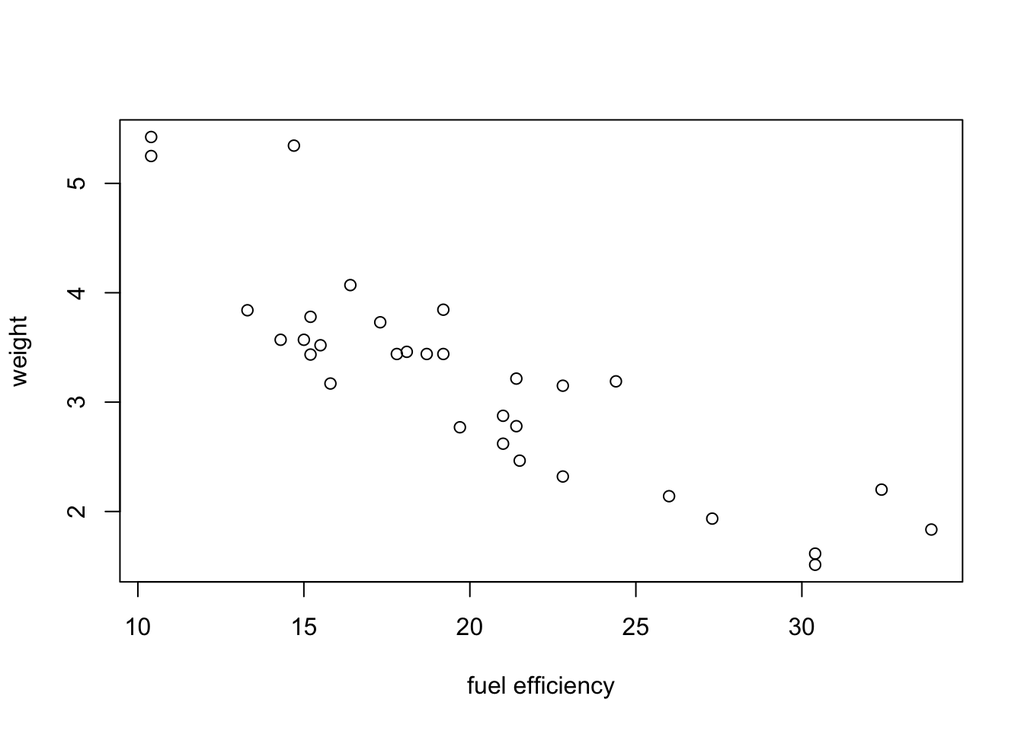

```r
#(e)
plot(mtcars$mpg, mtcars$wt, xlab = 'fuel efficiency', ylab = 'weight')
```